# ps03

```python
import pandas as pd
import matplotlib.pyplot as plt
import numpy as np
```

### Q.1 Binomial distribution

```python
s, p = 3, 0.6
RV = np.random.binomial(s, p, size=5)
RV
```

```
array([3, 2, 3, 2, 1])
```

```python
#1 What is the expected value of this RV E X?
expected_value = s * p
expected_value
```

```
1.7999999999999998
```

- A binomial distribution's expected value is calculated by multiplying the sample size (s) by the probability of successes (p). So, the expected value is about 1.8.

```python
#2 What is the probability your get 0, 1, 2 or 3 “successes”?
zero = (0.6)**0 * (0.4)**3
one = ((3*2*1) / ((1) * (2*1))) * (0.6)**1 * (0.4)**2
two = ((3*2*1) / ((2*1) * (1))) * (0.6)**2 * (0.4)**1
three = (0.6)**3 * (0.4)**0
zero, one, two, three
```

```
(0.06400000000000002,
 0.28800000000000003,
 0.43200000000000005,
 0.21599999999999997)
```

- The probability I get 0 success is about 0.06. The probability I get 1 success is about 0.29. The probability I get 2 successes is about 0.43. The probability I get 3 successes is about 0.22.

```python
#3 What is variance of this RV Var X?
var = s * p * (0.4)
var
```

```
0.72
```

- A binomial distribution's variance is calculated by multiplying the expected value by the (1 - probability). So the variance of this RV is 0.72.

```python
#4 Pick a sample size R (1000...100,000 are good numbers) and create a sample of size R of such random values.
R = 100000
new_RV = np.random.binomial(s, p, size=R)
```

- I chose a new sample of size 100000.

```python
#5 Compute the mean of your sample.
np.mean(new_RV)
```

```
1.80277
```

- The mean of new RV is about 1.8.

```python
#6 Compute the variance of your sample.
np.var(new_RV)
```

```
0.7208103270999998
```

- The variance of new RV is about 0.72.

```python
#7 Given your sample size, what are the expected number of cases with 0, 1, 2, and 3 successes?
new_zero = 0.06 * 1000
new_one = 0.29 * 1000
new_two = 0.43 * 1000
new_three = 0.22 *1000
new_zero, new_one, new_two, new_three
```

```
(60.0, 290.0, 430.0, 220.0)
```

```python
#8 Make a histogram of your sample.
successes = [0, 1, 2, 3]
counts = [new_zero, new_one, new_two, new_three]
```

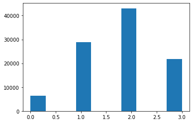

```python
plt.hist(new_RV)
```

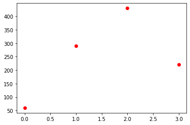

```python
plt.scatter(successes, counts, c="red")
```

- The histogram and the scatterplot matches well. Both the random number and the expected number of 2 successes is the highest, and both the random number and the expected number of 0 success is the lowest. Plus,the number of 1 success is higher than that of 3 successes in both graph.

### Q.2 Log-normal distribution

```python
#1 Choose your sample size S. 10,000 is a good number.
mean = 0
sigma = 1
RL = np.random.lognormal(mean, sigma, size=10000)
RL
```

```
array([2.53648321, 0.15031316, 0.4205048 , ..., 0.95903315, 1.29741534,
       0.54948659])
```

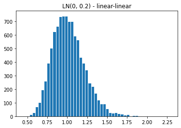

```python
#2 Explore the shape of the distribution
mean = 0
sigma = 0.2
RL_one = np.random.lognormal(mean, sigma, size=10000)

plt.hist(RL_one, edgecolor ='w', bins=50)
plt.title('LN(0, 0.2) - linear-linear')
```

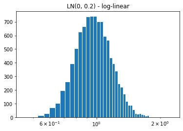

```python
plt.hist(RL_one, edgecolor ='w', bins=50)
plt.xscale('log')
plt.yscale('linear')
plt.title('LN(0, 0.2) - log-linear')
```

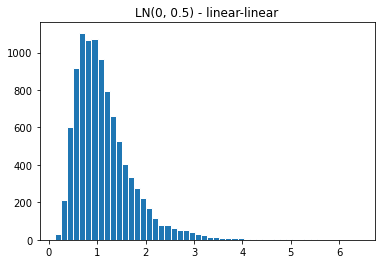

```python
mean = 0
sigma = 0.5
RL_two = np.random.lognormal(mean, sigma, size=10000)

plt.hist(RL_two, edgecolor ='w', bins=50)
plt.title('LN(0, 0.5) - linear-linear')
```

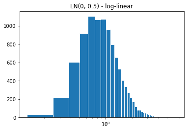

```python
plt.hist(RL_two, edgecolor ='w', bins=50)
plt.xscale('log')
plt.yscale('linear')
plt.title('LN(0, 0.5) - log-linear')
```

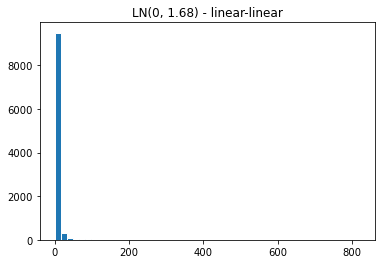

```python
mean = 0
sigma = 1.68
RL_three = np.random.lognormal(mean, sigma, size=10000)

plt.hist(RL_three, edgecolor ='w', bins=50)
plt.title('LN(0, 1.68) - linear-linear')
```

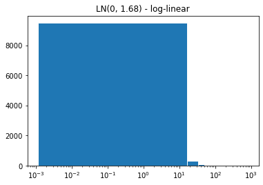

```python
plt.hist(RL_three, edgecolor ='w', bins=50)
plt.xscale('log')
plt.yscale('linear')
plt.title('LN(0, 1.68) - log-linear')
```

- All graphs skewed to the right, but the larger the variance gets, the skewer the graph gets to the right. The log graph of LN(0,0.5) and LN(0,1.68) do not look normal since the bin width is to wide.

```python
#3 Look at the histograms and tell-what do you think, which one describes the least unequal distribution,
#  and which one the most unequal distribution?
```

- I think the 'LN(0, 0.2)' graph descirbes the least unequal distribution, while the 'LN(0, 1.68)' graph describes the most unequal distribution.

```python
#4 Compute sample means and variance, and compare those with what you get using the corresponding theoretical formulas.
e = 2.718281828459045
np.mean(RL_one), e**(0 + 1/2 * 0.2**2), np.var(RL_one), e**(2 * 0 + 0.2**2) * (e**(0.2**2) - 1)
```

```
(1.0184872645697458,
 1.0202013400267558,
 0.042134724369827445,
 0.04247629348257031)
```

```python
np.mean(RL_two), e**(0 + 1/2 * 0.5**2), np.var(RL_two), e**(2 * 0 + 0.5**2) * (e**(0.5**2) - 1)
```

```
(1.1373863012136123,
 1.1331484530668263,
 0.3697686877560255,
 0.3646958540123865)
```

```python
np.mean(RL_three), e**(0 + 1/2 * 1.68**2), np.var(RL_three), e**(2 * 0 + 1.68**2) * (e**(1.68**2) - 1)
```

```
(4.09218774071618, 4.1008735008239405, 214.69304606293616, 265.99982369887033)
```

- The less inequality, the more similar the theoretical and sample values are. The first sample with 0 log-mean and 0.2 log-variance has the least inequality and its theoretical and sample values are the most similar, while the last sample with 0 log-mean and 1.68 log- variance has the most ineqality and its each values are the least similar.

```python
#5 Compute the Pareto ratio of all three samples.
RL_one_20 = (RL_one >= np.percentile(RL_one, 80))
RL_one_20.sum()/RL_one.sum()
```

```
0.19636966210322607
```

```python
RL_two_20 = (RL_two >= np.percentile(RL_two, 80))
RL_two_20.sum()/RL_two.sum()
```

```
0.17584175208246863
```

```python
RL_three_20 = (RL_three >= np.percentile(RL_three, 80))
RL_three_20.sum()/RL_three.sum()
```

```
0.04887361300901549
```

### Q.3 Inequality in data

```python
#1 Load both datasets and do basic checks—do the values of interest (number of citations and income) look reasonable?
treatment = pd.read_csv("../data/treatment.csv.bz2", sep="\t")
citation = pd.read_csv("../data/mag-30k-citations.csv.bz2", sep="\t")
```

```python
income = treatment[["re78"]]
income
```

|  | re78 |
| --- | --- |
| 0 | 9930.05 |
| 1 | 24909.50 |
| 2 | 7506.15 |
| 3 | 289.79 |
| 4 | 4056.49 |
| ... | ... |
| 2670 | 38568.70 |
| 2671 | 59109.10 |
| 2672 | 55710.30 |
| 2673 | 20540.40 |
| 2674 | 53198.20 |

2675 rows × 1 columns

```python
citations = citation[["citations"]]
citations
```

|  | citations |
| --- | --- |
| 0 | 10 |
| 1 | 0 |
| 2 | 3 |
| 3 | 0 |
| 4 | 42 |
| ... | ... |
| 29995 | 0 |
| 29996 | 1 |
| 29997 | 0 |
| 29998 | 11 |
| 29999 | 84 |

30000 rows × 1 columns

- Yes, they look reasonable.

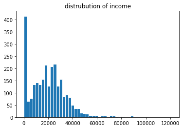

```python
#2  Show the distribution of income and citations on a histogram.
plt.hist(income, edgecolor ='w', bins=50)
plt.title("distrubution of income")
```

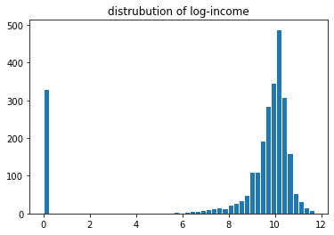

```python
plt.hist(np.log(1+income), edgecolor ='w', bins=50)
plt.title("distrubution of log-income")
plt.yscale('linear')
```

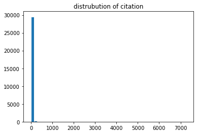

```python
plt.hist(citations, edgecolor ='w', bins=50)
plt.title("distrubution of citation")
```

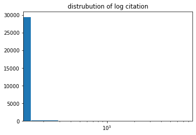

```python
plt.hist(citations, edgecolor ='w', bins=50)
plt.title("distrubution of log citation")
plt.xscale('log')
plt.yscale('linear')
```

```python
#3 Compute sample mean and standard deviation for both datasets.
#  Compare these: how much smaller (or larger) is std. dev compared to the mean?
np.mean(income), np.var(income)**0.5
```

```
(re78    20502.376079
 dtype: float64,
 re78    15629.597535
 dtype: float64)
```

```python
np.mean(citations), np.var(citations)**0.5
```

```
(citations    15.605633
 dtype: float64,
 citations    79.176783
 dtype: float64)
```

- The standard deviation in income dataset is about 4873 smaller than its mean, while the standard deviation in citations dataset is about 64 larger than its mean.

```python
#4 Compute the Pareto ratio for both distributions.
income_20 = income[income.re78 >= income.re78.quantile(.8)]
income_20.re78.sum()/income.re78.sum()
```

```
0.4339874223192208
```

```python
citation_20 = citations[citations.citations >= citations.citations.quantile(.8)]
citation_20.citations.sum()/citations.citations.sum()
```

```
0.869156223500488
```

- The Pareto ratio for income distribution is about 0.43, and that for citation distribution is about 0.87.

### Q.4 Variance of mean

```python
#1  Pick your number of repetitions R.
s, p = 3, 0.6
R = 100000
```

- I chose 100000 as the number of repetitions R.

```python
#2 Now do R times in a loop: create a single realization of this RV.
realization = []
for i in range(R):
    n_RV = np.random.binomial(s, p)
    realization.append(n_RV)
```

- 'Realization' is a single realization of the RV.

```python
#3 Compute variance of your sample.
np.var(realization)
```

```
0.7219274375000001
```

- The variance of the sample is about 0.72.

```python
#4 Do a loop of R again, but this time create a pair of realizations (S = 2).
#  Compute the pair mean, and store it in a vector. You should have R pair means.
pair_realization = []
S = 2
for i in range(R):
    n_RV = np.random.binomial(s, p, size=S)
    pair_realization.append(n_RV)
```

```python
pair_ = np.array(pair_realization)
pair_mean = np.mean(pair_, axis=1)
pair_mean
```

```
array([2.5, 2. , 1. , ..., 1. , 2.5, 2. ])
```

- 'Pair_mean' is a vector of R pair means.

```python
#5 Compute variance of your pair means.
np.var(pair_mean)
```

```
0.3637684997749999
```

- The variance of the pair means is about 0.36.

```python
#6  Repeat with S = 10-tuples and with S = 100-tuples. In both cases compute variance.
realizations = []
S = 10
for i in range(R):
    n_RV = np.random.binomial(s, p, size=S)
    realizations.append(n_RV)
```

```python
index_mean = np.array(realizations)
mean = np.mean(index_mean, axis=1)
mean
```

```
array([2.2, 1.8, 1.2, ..., 2. , 2.1, 1.7])
```

```python
np.var(mean)
```

```
0.07232058150399999
```

```python
new_realizations = []
S = 100
for i in range(R):
    n_RV = np.random.binomial(s, p, size=S)
    new_realizations.append(n_RV)
```

```python
index_means = np.array(new_realizations)
means = np.mean(index_means, axis=1)
means
```

```
array([1.84, 1.72, 1.7 , ..., 1.77, 1.78, 1.7 ])
```

```python
np.var(means)
```

```
0.00722642496351
```

- The variance of means in S = 10-tuples is about 0.07, and the variance of means in S = 100-tuples is about 0.007.

```python
#7  Explain why variance of mean gets smaller when sample size S gets larger.
```

- As the sample size increases, the variance of mean decreases since the sample size is in the denominator in the formula for calculating variance. The more samples, the closer the results are to the mean value.
- I spent about 7 hours for this assignment.